# Credit Card Users Churn Prediction

#### **Attrition_Flag Vs Avg_Utilization_Ratio**

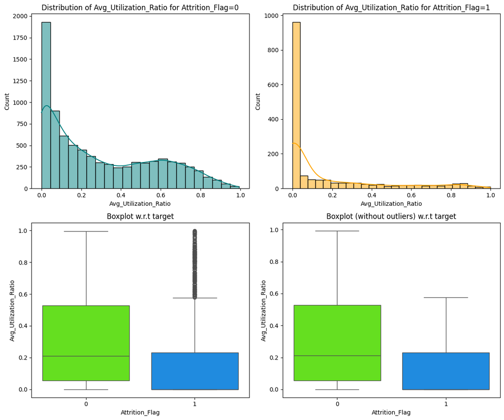

```python
# Lets analyse continuous variables
# Attrition_Flag Vs Avg_Utilization_Ratio
distribution_plot_wrt_target(data, "Avg_Utilization_Ratio", "Attrition_Flag")
```

## Data Pre-processing

### **Outlier Detection**

```python
# Select only numeric columns
numeric_cols = data.select_dtypes(include=['float64', 'int64']).columns
numeric_data = data[numeric_cols]

# Now calculate quantiles
Q1 = numeric_data.quantile(0.25)  # To find the 25th percentile
Q3 = numeric_data.quantile(0.75)  # To find the 75th percentile

IQR = Q3 - Q1  # Inter Quantile Range (75th percentile - 25th percentile)

# Calculate bounds for outliers
lower_bound = Q1 - 1.5 * IQR
upper_bound = Q3 + 1.5 * IQR
```

```python
# checking the % outliers
((data.select_dtypes(include=["float64", "int64"]) < lower_bound) | (data.select_dtypes(include=["float64", "int64"]) > upper_bound)).sum() / len(data) * 100
```

|  | 0 |
| --- | --- |
| Attrition_Flag | 16.066 |
| Customer_Age | 0.020 |
| Dependent_count | 0.000 |
| Months_on_book | 3.812 |
| Total_Relationship_Count | 0.000 |
| Months_Inactive_12_mon | 3.268 |
| Contacts_Count_12_mon | 6.211 |
| Credit_Limit | 9.717 |
| Total_Revolving_Bal | 0.000 |
| Avg_Open_To_Buy | 9.509 |
| Total_Amt_Chng_Q4_Q1 | 3.910 |
| Total_Trans_Amt | 8.848 |
| Total_Trans_Ct | 0.020 |
| Total_Ct_Chng_Q4_Q1 | 3.891 |
| Avg_Utilization_Ratio | 0.000 |

**dtype:** float64

#### **Observation**

- Credit_Limit (9.717%), Avg_Open_To_Buy (9.5%), Total_Trans_Amt (8.848%) and Contact_Count_12_mon (6.2%) have more than 5% outliers.
- Thought there are outlier we are not going to treat them.

### **Treat Income_Category**

- As we noticed in our previous analysis, Income_Category has a significat records with value "abc" which could be a dataentry issue. We will fix it by setting the abc value to NaN

```python
# Checking the values of the Income_Category column.
data['Income_Category'].value_counts()
```

|  | Income_Category |
| --- | --- |
| Less than $40K | 3561 |
| $40K - $60K | 1790 |
| $80K - $120K | 1535 |
| $60K - $80K | 1402 |
| abc | 1112 |
| $120K + | 727 |

**dtype:** int64

```python
# Replacing "abc" entries in the Income_Category column with np.nan.
data['Income_Category'].replace('abc', np.nan, inplace=True)
```

```python
# Checking the values of the Income_Category column after treatment
data['Income_Category'].value_counts()
```

|  | Income_Category |
| --- | --- |
| Less than $40K | 3561 |
| $40K - $60K | 1790 |
| $80K - $120K | 1535 |
| $60K - $80K | 1402 |
| $120K + | 727 |

**dtype:** int64

#### **Observation**

- There wre 1112 records with value "abc", replaced "abc" value with np.nan
- We can impute the missing value latter.

### Train-Test Split

To avoid any data leak lets split the data and then treat them for missing data

```python
# Chech for missing data
data.isna().sum()
```

|  | 0 |
| --- | --- |
| Attrition_Flag | 0 |
| Customer_Age | 0 |
| Gender | 0 |
| Dependent_count | 0 |
| Education_Level | 1519 |
| Marital_Status | 749 |
| Income_Category | 1112 |
| Card_Category | 0 |
| Months_on_book | 0 |
| Total_Relationship_Count | 0 |
| Months_Inactive_12_mon | 0 |
| Contacts_Count_12_mon | 0 |
| Credit_Limit | 0 |
| Total_Revolving_Bal | 0 |
| Avg_Open_To_Buy | 0 |
| Total_Amt_Chng_Q4_Q1 | 0 |
| Total_Trans_Amt | 0 |
| Total_Trans_Ct | 0 |
| Total_Ct_Chng_Q4_Q1 | 0 |
| Avg_Utilization_Ratio | 0 |

**dtype:** int64

**Observation**

- Education_Level (1519), Marital_Status (749), Income_Category(1112) has missing values.

```python
#Take a copy of original data
data_original = data.copy()
```

```python
# Split feature and target variables
X = data_original.drop('Attrition_Flag', axis=1)
y = data_original['Attrition_Flag']
```

```python
# Spliting data into training, validation and test set.
# First split: Separate test set (20% of data)
X_train_val, X_test, y_train_val, y_test = train_test_split(X, y, test_size=0.2, random_state=1)

# Second split: Separate train and validation sets (validation is 25% of remaining 80% ≈ 20% of total)
X_train, X_val, y_train, y_val = train_test_split(X_train_val, y_train_val, test_size=0.25, random_state=1)

# Print shapes to verify split
print("Training set shape:", X_train.shape)
print("Validation set shape:", X_val.shape)
print("Test set shape:", X_test.shape)

# Print class distribution in each set
print("\nClass distribution in training set:")
print(y_train.value_counts(normalize=True))
print("\nClass distribution in validation set:")
print(y_val.value_counts(normalize=True))
print("\nClass distribution in test set:")
print(y_test.value_counts(normalize=True))
```

```
Training set shape: (6075, 19)
Validation set shape: (2026, 19)
Test set shape: (2026, 19)

Class distribution in training set:
0   0.841
1   0.159
Name: Attrition_Flag, dtype: float64

Class distribution in validation set:
0   0.838
1   0.162
Name: Attrition_Flag, dtype: float64

Class distribution in test set:
0   0.837
1   0.163
Name: Attrition_Flag, dtype: float64
```

**Observation**

- Training set shape: (6075, 19)
- Validation set shape: (2026, 19)
- Test set shape: (2026, 19)
- Class distribution in training set:
  - Attrition_Flag
    - 0 - 0.841
    - 1 - 0.159
- Class distribution in validation set:
  - Attrition_Flag
  - 0 - 0.838
  - 1 - 0.162
- Class distribution in test set:
  - Attrition_Flag
  - 0 - 0.837
  - 1 - 0.163

**The distribution is propotional on training, validation and test dataset**

## Missing value imputation

```python
# columns with missing values
columns_with_missing_values = ["Education_Level", "Marital_Status", "Income_Category"]
# creating an instace of the imputer to be used
imputer = SimpleImputer(strategy="most_frequent")
```

```python
# Fit and transform the train data
X_train[columns_with_missing_values] = imputer.fit_transform(X_train[columns_with_missing_values])

# Transform the validation data
X_val[columns_with_missing_values]  =  imputer.transform(X_val[columns_with_missing_values])
# Transform the test data
X_test[columns_with_missing_values] = imputer.transform(X_test[columns_with_missing_values])
```

```python
# Checking that no column has missing values in train, validation or test sets
print("Training dataset")
print("-" * 30)
print(X_train.isna().sum())
print("=" * 30)
print("Validation dataset")
print("-" * 30)
print(X_val.isna().sum())
print("=" * 30)
print("Test dataset")
print("-" * 30)
print(X_test.isna().sum())
```

```
Training dataset
------------------------------
Customer_Age                0
Gender                      0
Dependent_count             0
Education_Level             0
Marital_Status              0
Income_Category             0
Card_Category               0
Months_on_book              0
Total_Relationship_Count    0
Months_Inactive_12_mon      0
Contacts_Count_12_mon       0
Credit_Limit                0
Total_Revolving_Bal         0
Avg_Open_To_Buy             0
Total_Amt_Chng_Q4_Q1        0
Total_Trans_Amt             0
Total_Trans_Ct              0
Total_Ct_Chng_Q4_Q1         0
Avg_Utilization_Ratio       0
dtype: int64
==============================
Validation dataset
------------------------------
Customer_Age                0
Gender                      0
Dependent_count             0
Education_Level             0
Marital_Status              0
Income_Category             0
Card_Category               0
Months_on_book              0
Total_Relationship_Count    0
Months_Inactive_12_mon      0
Contacts_Count_12_mon       0
Credit_Limit                0
Total_Revolving_Bal         0
Avg_Open_To_Buy             0
Total_Amt_Chng_Q4_Q1        0
```

[output cut: 13 more lines]

```
Income_Category             0
Card_Category               0
Months_on_book              0
Total_Relationship_Count    0
Months_Inactive_12_mon      0
Contacts_Count_12_mon       0
Credit_Limit                0
Total_Revolving_Bal         0
Avg_Open_To_Buy             0
Total_Amt_Chng_Q4_Q1        0
Total_Trans_Amt             0
Total_Trans_Ct              0
Total_Ct_Chng_Q4_Q1         0
Avg_Utilization_Ratio       0
dtype: int64
```

**Observation**

- No missing values in all 3 dataset.

### **Encoding categorical variables**

- Identify categorical columns in the dataset and convert them to category
- Benefits
  - Memory efficienty
  - Better performance
  - More appropriate representation of categorical data.

#### **Train Dataset**

```python
# Check Categorical column
cols = X_train.select_dtypes(include=["object", "category"])
for i in cols.columns:
    print(X_train[i].value_counts())
    print("-" * 30)
```

```
F    3211
M    2864
Name: Gender, dtype: int64
------------------------------
Graduate         2800
High School      1188
Uneducated        908
College           606
Post-Graduate     296
Doctorate         277
Name: Education_Level, dtype: int64
------------------------------
Married     3294
Single      2327
Divorced     454
Name: Marital_Status, dtype: int64
------------------------------
Less than $40K    2812
$40K - $60K       1059
$80K - $120K       946
$60K - $80K        818
$120K +            440
Name: Income_Category, dtype: int64
------------------------------
Blue        5661
Silver       339
Gold          65
Platinum      10
Name: Card_Category, dtype: int64
------------------------------
```

#### **Validation Dataset**

```python
# Check Categorical column
cols = X_val.select_dtypes(include=["object", "category"])
for i in cols.columns:
    print(X_val[i].value_counts())
    print("-" * 30)
```

```
F    1086
M     940
Name: Gender, dtype: int64
------------------------------
Graduate         903
High School      413
Uneducated       302
College          208
Post-Graduate    113
Doctorate         87
Name: Education_Level, dtype: int64
------------------------------
Married     1071
Single       796
Divorced     159
Name: Marital_Status, dtype: int64
------------------------------
Less than $40K    932
$40K - $60K       378
$60K - $80K       296
$80K - $120K      282
$120K +           138
Name: Income_Category, dtype: int64
------------------------------
Blue        1873
Silver       122
Gold          23
Platinum       8
Name: Card_Category, dtype: int64
------------------------------
```

#### **Test Dataset**

```python
# Check Categorical column
cols = X_test.select_dtypes(include=["object", "category"])
for i in cols.columns:
    print(X_test[i].value_counts())
    print("-" * 30)
```

```
F    1061
M     965
Name: Gender, dtype: int64
------------------------------
Graduate         944
High School      412
Uneducated       277
College          199
Post-Graduate    107
Doctorate         87
Name: Education_Level, dtype: int64
------------------------------
Married     1071
Single       820
Divorced     135
Name: Marital_Status, dtype: int64
------------------------------
Less than $40K    929
$40K - $60K       353
$80K - $120K      307
$60K - $80K       288
$120K +           149
Name: Income_Category, dtype: int64
------------------------------
Blue        1902
Silver        94
Gold          28
Platinum       2
Name: Card_Category, dtype: int64
------------------------------
```

#### **Create Dummy Variable**

```python
print("Shape of dataset before encoding.")
print("-" * 30)
print(f"Train dataset: {X_train.shape}\nValidation dataset: {X_val.shape}\nTest dataset: {X_test.shape}")
print("=" * 30)
# Train dataset
X_train = pd.get_dummies(X_train, drop_first=True)
X_train = X_train.astype(float)

# Validation dataset
X_val = pd.get_dummies(X_val, drop_first=True)
X_val = X_val.astype(float)

# Test dataset
X_test = pd.get_dummies(X_test, drop_first=True)
X_test = X_test.astype(float)

print("Shape of dataset after encoding.")
print("-" * 30)
print(f"Train dataset: {X_train.shape}\nValidation dataset: {X_val.shape}\nTest dataset: {X_test.shape}")
print("=" * 30)
```

```
Shape of dataset before encoding.
------------------------------
Train dataset: (6075, 19)
Validation dataset: (2026, 19)
Test dataset: (2026, 19)
==============================
Shape of dataset after encoding.
------------------------------
Train dataset: (6075, 29)
Validation dataset: (2026, 29)
Test dataset: (2026, 29)
==============================
```

**Observation**

- Shape of dataset before encoding.
  - Train dataset: (6075, 19)
  - Validation dataset: (2026, 19)
  - Test dataset: (2026, 19)
- Shape of dataset after encoding.
  - Train dataset: (6075, 29)
  - Validation dataset: (2026, 29)
  - Test dataset: (2026, 29)

**After creating dummies for categorical variables, there are 29 columns**

```python
# check the top 5 rows from the train dataset
X_train.head()
```

|  | Customer_Age | Dependent_count | Months_on_book | Total_Relationship_Count | Months_Inactive_12_mon | Contacts_Count_12_mon | Credit_Limit | Total_Revolving_Bal | Avg_Open_To_Buy | Total_Amt_Chng_Q4_Q1 | Total_Trans_Amt | Total_Trans_Ct | Total_Ct_Chng_Q4_Q1 | Avg_Utilization_Ratio | Gender_M | Education_Level_Doctorate | Education_Level_Graduate | Education_Level_High School | Education_Level_Post-Graduate | Education_Level_Uneducated | Marital_Status_Married | Marital_Status_Single | Income_Category_$40K - $60K | Income_Category_$60K - $80K | Income_Category_$80K - $120K | Income_Category_Less than $40K | Card_Category_Gold | Card_Category_Platinum | Card_Category_Silver |
| --- | --- | --- | --- | --- | --- | --- | --- | --- | --- | --- | --- | --- | --- | --- | --- | --- | --- | --- | --- | --- | --- | --- | --- | --- | --- | --- | --- | --- | --- |
| 7321 | 47.000 | 1.000 | 40.000 | 3.000 | 1.000 | 3.000 | 3811.000 | 1970.000 | 1841.000 | 0.828 | 3578.000 | 76.000 | 0.689 | 0.517 | 0.000 | 0.000 | 1.000 | 0.000 | 0.000 | 0.000 | 0.000 | 1.000 | 0.000 | 0.000 | 0.000 | 1.000 | 0.000 | 0.000 | 0.000 |
| 2276 | 45.000 | 1.000 | 36.000 | 6.000 | 2.000 | 2.000 | 9433.000 | 1578.000 | 7855.000 | 0.660 | 3910.000 | 81.000 | 0.653 | 0.167 | 0.000 | 0.000 | 0.000 | 1.000 | 0.000 | 0.000 | 0.000 | 0.000 | 0.000 | 0.000 | 0.000 | 1.000 | 0.000 | 0.000 | 0.000 |
| 4574 | 39.000 | 1.000 | 35.000 | 5.000 | 3.000 | 0.000 | 2062.000 | 1302.000 | 760.000 | 0.631 | 3785.000 | 63.000 | 0.750 | 0.631 | 0.000 | 0.000 | 0.000 | 0.000 | 0.000 | 1.000 | 0.000 | 1.000 | 0.000 | 0.000 | 0.000 | 1.000 | 0.000 | 0.000 | 0.000 |
| 7064 | 50.000 | 2.000 | 44.000 | 3.000 | 1.000 | 2.000 | 3386.000 | 2517.000 | 869.000 | 0.743 | 4890.000 | 65.000 | 0.667 | 0.743 | 0.000 | 0.000 | 0.000 | 0.000 | 0.000 | 1.000 | 1.000 | 0.000 | 0.000 | 0.000 | 0.000 | 1.000 | 0.000 | 0.000 | 0.000 |
| 1350 | 31.000 | 2.000 | 20.000 | 3.000 | 1.000 | 2.000 | 8149.000 | 0.000 | 8149.000 | 0.331 | 808.000 | 30.000 | 0.111 | 0.000 | 0.000 | 0.000 | 1.000 | 0.000 | 0.000 | 0.000 | 1.000 | 0.000 | 0.000 | 0.000 | 0.000 | 1.000 | 0.000 | 0.000 | 0.000 |